# LBB10

### Holt-Winters

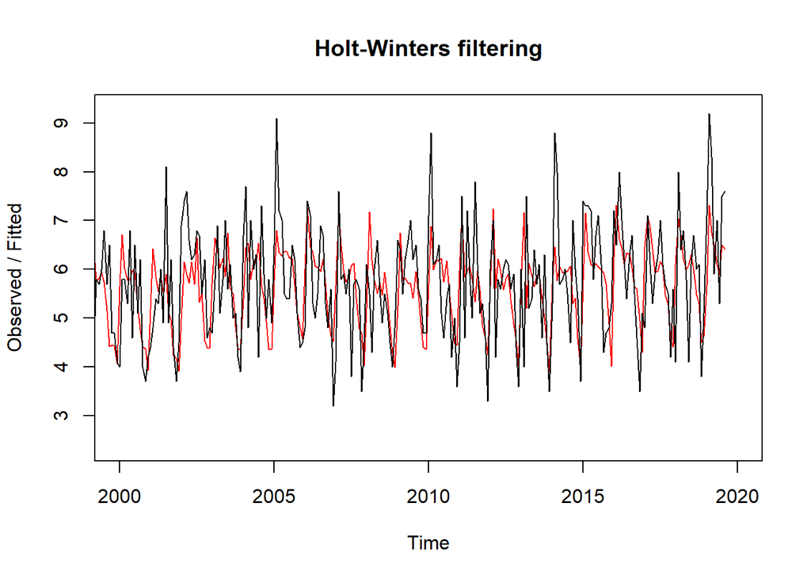

```r
#create holt-winters model
sunshine_hw <- HoltWinters(sunshine_ts)

#plot model
plot(sunshine_hw, xlim=c(2000,2020))

#forecast
library(forecast)
```

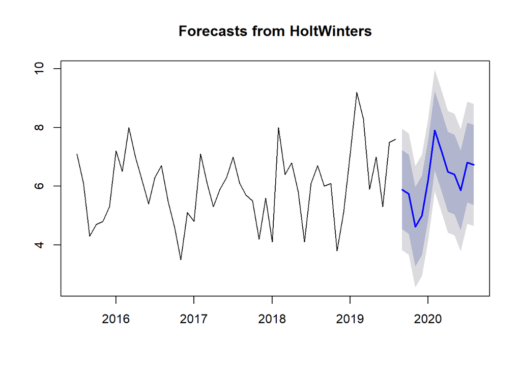

```r
sunshine_hwf <- forecast(sunshine_hw, h = 12)
plot(sunshine_hwf, include = 50)
```

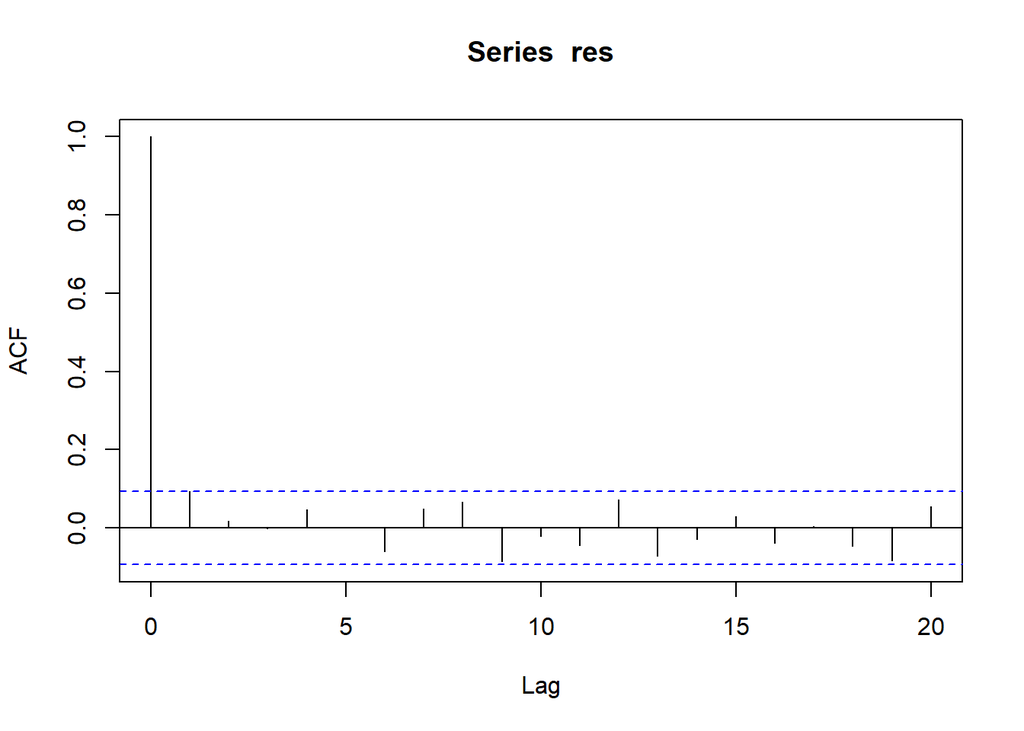

```r
#acf & pacf
res <- sunshine_hwf$residuals[!is.na(sunshine_hwf$residuals)]
acf(res, lag.max = 20)
```

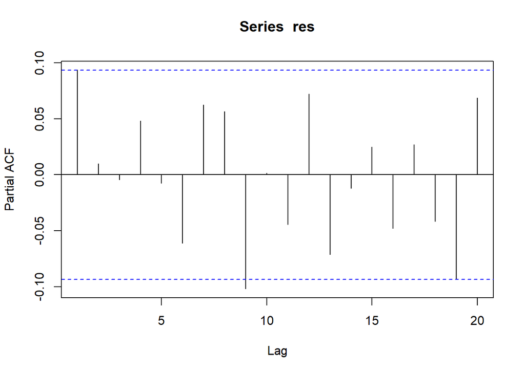

```r
pacf(res, lag.max = 20)
```

```r
#Many autocorrelations are close to significance lines(blue lines). Not a good sign.

#Ljung-Box Test
Box.test(res,type = "Ljung-Box")
```

```
##
##  Box-Ljung test
##
## data:  res
## X-squared = 3.8839, df = 1, p-value = 0.04875
```

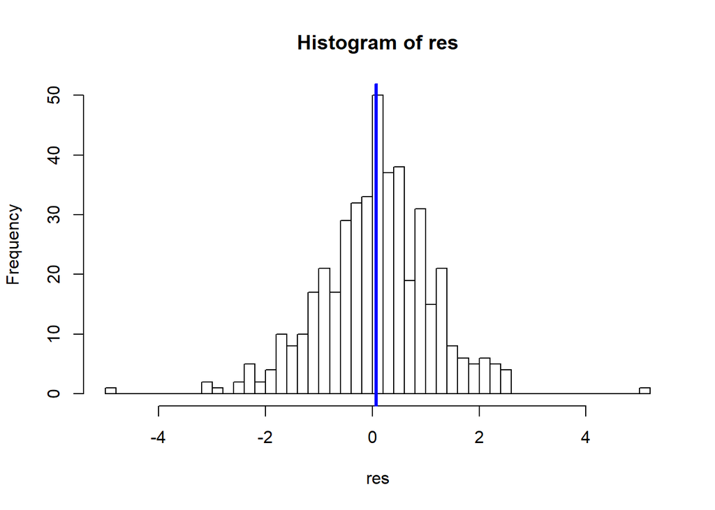

```r
#p-value <0.05 Null hypothesis(no correlation) is rejected. There is autocorrelation in model.

#Histogram (check for normal distribution)
hist(res, breaks = 50)
abline(v = mean(res), col = "blue", lwd = 3)
```

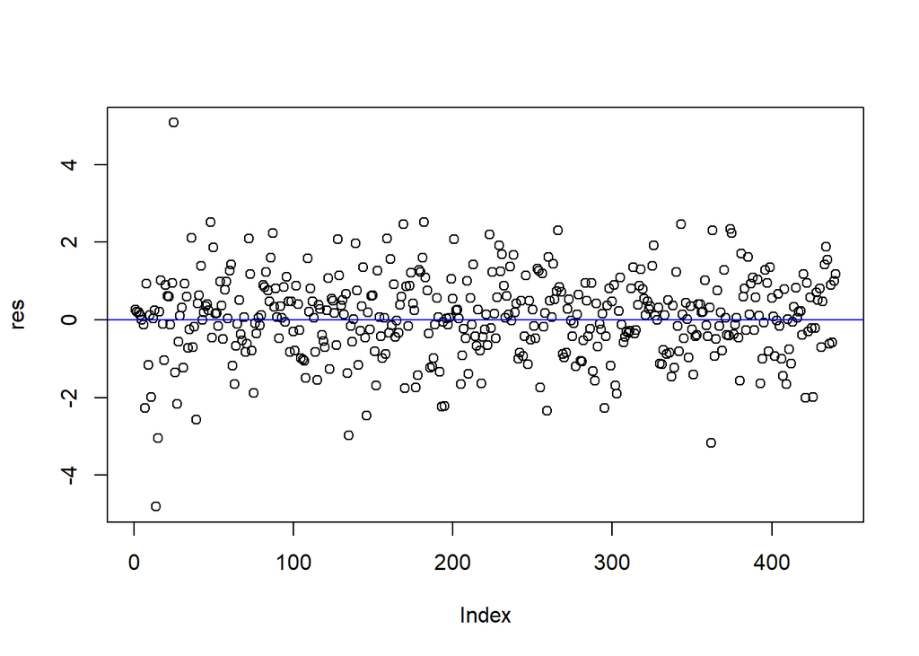

```r
#looks normally distributed, mean of residuals is close to zero

#Plot Residuals (check for constant variance)
plot(res, type = "p")
abline(h=0, col = "blue")
```

```r
#variance is constant, great!
```

While there are some autocorrelations in the Holt-Winters model, subsequent histogram plot show that mean of residuals is close to zero and residuals are normally distributed. That suggests that most of the useful information from the time series has been utilized in the model. Also, the residuals have constant variance with the exception of 2 points. Thus, this model is valid.

### ARIMA

```r
#adf test
library(tseries)
adf.test(sunshine_ts, k=12)
```

```
##
##  Augmented Dickey-Fuller Test
##
## data:  sunshine_ts
## Dickey-Fuller = -4.2468, Lag order = 12, p-value = 0.01
## alternative hypothesis: stationary
```

```r
#p=0.01 is good news, p<0.05 means that ts is stationary

# create ARIMA model
sunshine_A <- auto.arima(sunshine_ts)
sunshine_A
```

```
## Series: sunshine_ts
## ARIMA(2,0,1)(2,0,0)[12] with non-zero mean
##
## Coefficients:
##          ar1      ar2      ma1    sar1    sar2    mean
##       1.1858  -0.2453  -0.9591  0.3527  0.0835  5.6599
## s.e.  0.0575   0.0486   0.0387  0.0485  0.0530  0.0621
##
## sigma^2 estimated as 1.136:  log likelihood=-668.09
## AIC=1350.18   AICc=1350.44   BIC=1378.98
```

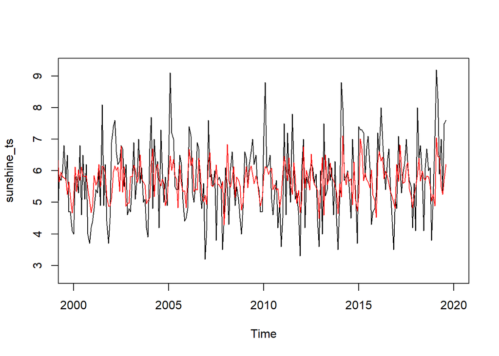

```r
plot(sunshine_ts, xlim=c(2000,2020))
lines(sunshine_A$fitted, col="red")
```

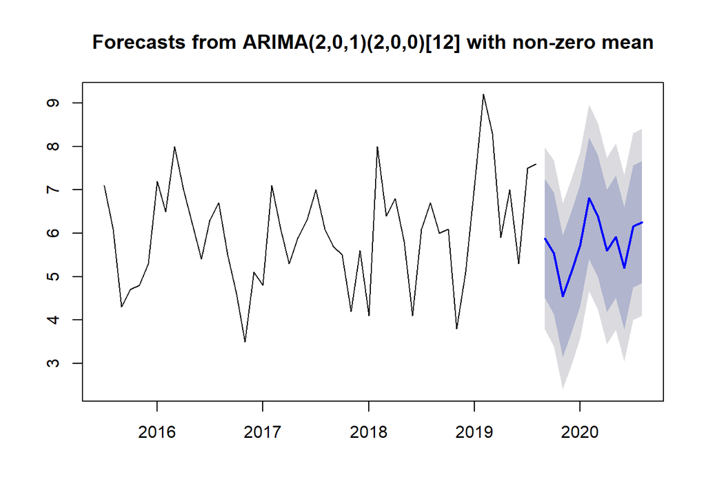

```r
#forecast
plot(forecast(sunshine_A, h = 12), include = 50)
```

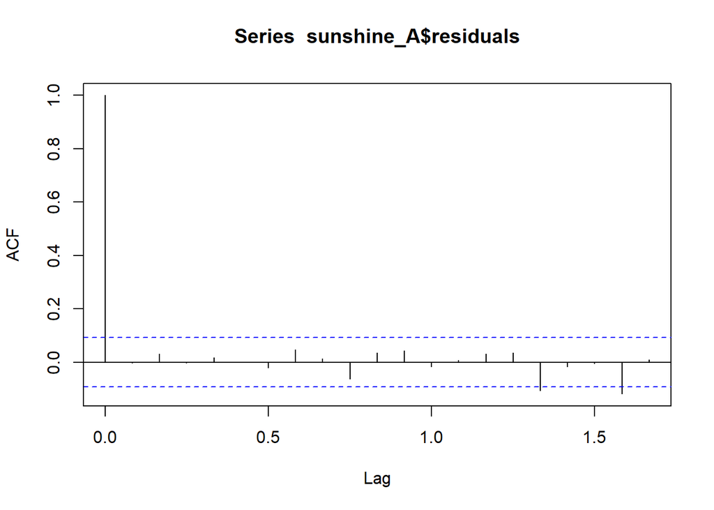

```r
#acf & pacf
acf(sunshine_A$residuals, lag.max = 20)
```

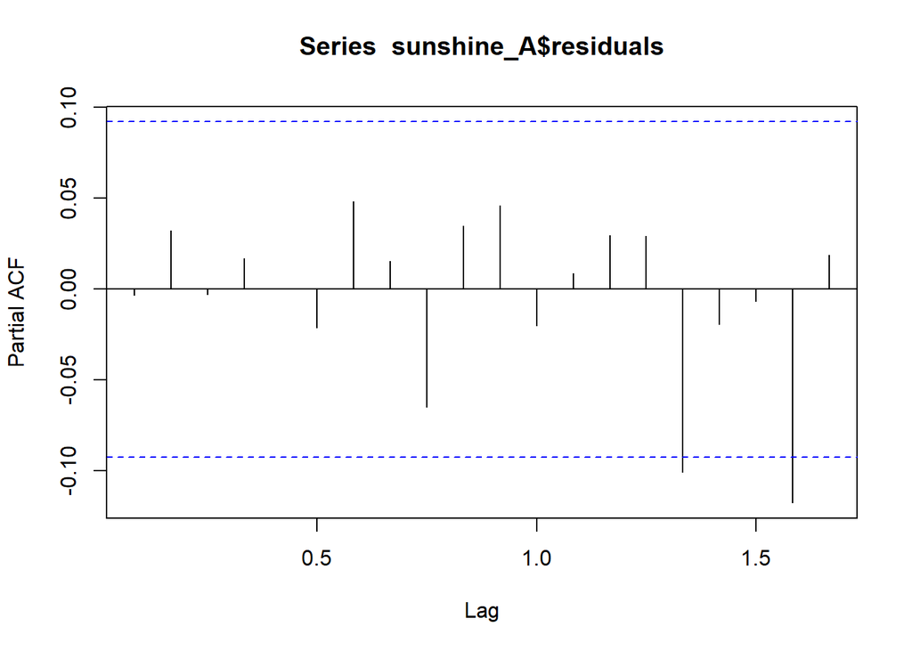

```r
pacf(sunshine_A$residuals, lag.max = 20)
```

```r
#2 points are outside of the significance boundaries. There is some autocorrelation

#Ljung-Box Test
Box.test(sunshine_A$residuals, type = "Ljung-Box")
```

```
##
##  Box-Ljung test
##
## data:  sunshine_A$residuals
## X-squared = 0.0045556, df = 1, p-value = 0.9462
```

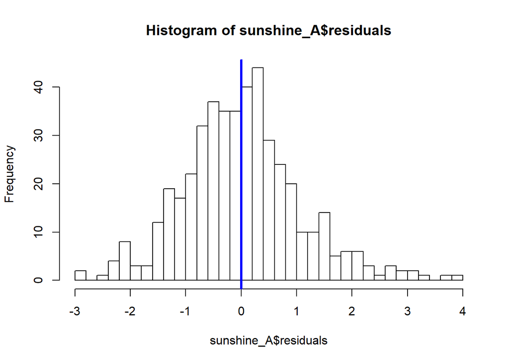

```r
#p-value >0.05, in fact very high. No autocorrelation

#Histogram (check for normal distribution)
hist(sunshine_A$residuals, breaks = 40)
abline(v = mean(sunshine_A$residuals), col = "blue", lwd = 3)
```

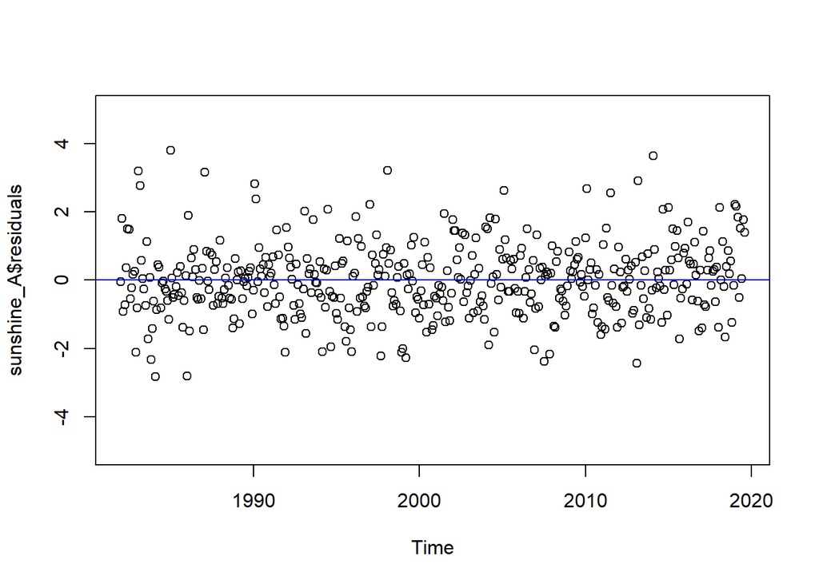

```r
#looks normally distributed, and mean is 0. Great!

#plot residuals (check for constant variance)
plot(sunshine_A$residuals, type = "p", ylim=c(-5,5))
abline(h=0, col="blue")
```

```r
#variance is fairly constant
```

The residuals of the ARIMA model shows that the model is valid. There is some autocorrelation but it is not significant. Also, the histogram plot shows that the residuals have a mean of zero and is normally distributed. There is also constant variance.

### Comparison

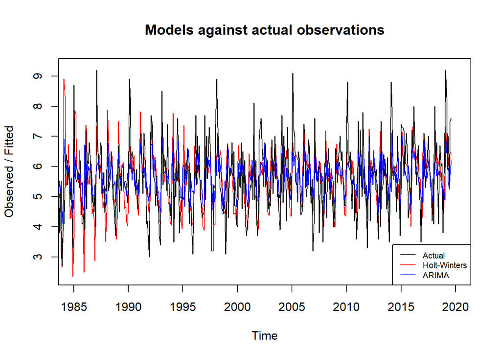

```r
#models
plot(sunshine_hw, xlim=c(1985,2020), main="Models against actual observations")
lines(sunshine_A$fitted, col="blue")
legend("bottomright", legend=c("Actual","Holt-Winters","ARIMA"), col=c("black","red","blue"), lwd=1, cex = 0.7)
```

It seems before year 2000, Holt-Winters performs worse than ARIMA. However, after year 2000, Holt-Winters models the observations better than ARIMA. At a glance, Holt-Winters seem to be better at modelling the big variations, while ARIMA appears to be more conservative in the modelling. Since big variations are common in past observations, the Holt-Winters model is more appropriate for forecasting mean sunshine duration than the ARIMA model.

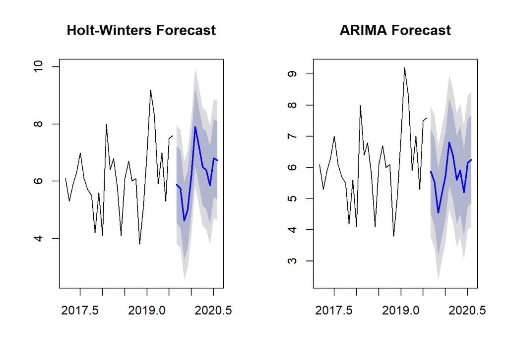

```r
#forecasts
par(mfrow=c(1,2))
plot(sunshine_hwf, include = 30, main="Holt-Winters Forecast")
plot(forecast(sunshine_A, h = 12), include = 30, main="ARIMA Forecast")
```